# Literacy 201802

coop711

2018-09-25

### barplot

막대그래프로 답안 분포를 시각적으로 살핀다. 차후 나오는 정답률과 함께 어느 문항에서 어느 답안을 많이 고르는지 파악하는 데 활용한다.

Counts

| Q1 | Q2 | Q3 | Q4 | Q5 | Q6 | Q7 | Q8 | Q9 | Q10 | Q11 | Q12 | Q13 | Q14 | Q15 | Q16 | Q17 | Q18 | Q19 | Q20 | Q21 | Q22 | Q23 | Q24 | Q25 |
| --- | --- | --- | --- | --- | --- | --- | --- | --- | --- | --- | --- | --- | --- | --- | --- | --- | --- | --- | --- | --- | --- | --- | --- | --- |
| 0 | 0 | 117 | 0 | 2 | 8 | 129 | 2 | 11 | 2 | 128 | 0 | 2 | 0 | 3 | 129 | 20 | 1 | 130 | 0 | 2 | 9 | 127 | 2 | 1 |
| 0 | 1 | 4 | 2 | 127 | 5 | 2 | 3 | 42 | 126 | 2 | 47 | 126 | 2 | 8 | 1 | 4 | 127 | 0 | 4 | 125 | 21 | 4 | 0 | 122 |
| 133 | 2 | 2 | 130 | 2 | 19 | 2 | 6 | 79 | 3 | 1 | 83 | 2 | 2 | 114 | 1 | 3 | 3 | 1 | 124 | 1 | 3 | 1 | 127 | 5 |
| 0 | 130 | 10 | 1 | 2 | 101 | 0 | 121 | 0 | 1 | 1 | 2 | 2 | 127 | 7 | 1 | 104 | 1 | 1 | 4 | 4 | 99 | 0 | 3 | 4 |

%

| Q1 | Q2 | Q3 | Q4 | Q5 | Q6 | Q7 | Q8 | Q9 | Q10 | Q11 | Q12 | Q13 | Q14 | Q15 | Q16 | Q17 | Q18 | Q19 | Q20 | Q21 | Q22 | Q23 | Q24 | Q25 |
| --- | --- | --- | --- | --- | --- | --- | --- | --- | --- | --- | --- | --- | --- | --- | --- | --- | --- | --- | --- | --- | --- | --- | --- | --- |
| 0 | 0 | 88 | 0 | 2 | 6 | 97 | 2 | 8 | 2 | 97 | 0 | 2 | 0 | 2 | 98 | 15 | 1 | 98 | 0 | 2 | 7 | 96 | 2 | 1 |
| 0 | 1 | 3 | 2 | 95 | 4 | 2 | 2 | 32 | 95 | 2 | 36 | 95 | 2 | 6 | 1 | 3 | 96 | 0 | 3 | 95 | 16 | 3 | 0 | 92 |
| 100 | 2 | 2 | 98 | 2 | 14 | 2 | 5 | 60 | 2 | 1 | 63 | 2 | 2 | 86 | 1 | 2 | 2 | 1 | 94 | 1 | 2 | 1 | 96 | 4 |
| 0 | 98 | 8 | 1 | 2 | 76 | 0 | 92 | 0 | 1 | 1 | 2 | 2 | 97 | 5 | 1 | 79 | 1 | 1 | 3 | 3 | 75 | 0 | 2 | 3 |

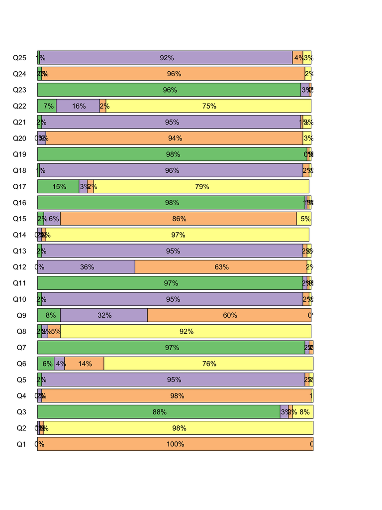

#### 문해력 점수 계산

##### 정답과 대조하여 R(Right)/W(Wrong) 표시

| A1 | A2 | A3 | A4 | A5 | A6 | A7 | A8 | A9 | A10 | A11 | A12 | A13 | A14 | A15 | A16 | A17 | A18 | A19 | A20 | A21 | A22 | A23 | A24 | A25 |
| --- | --- | --- | --- | --- | --- | --- | --- | --- | --- | --- | --- | --- | --- | --- | --- | --- | --- | --- | --- | --- | --- | --- | --- | --- |
| R | R | W | R | R | W | R | R | W | R | R | R | R | R | R | R | W | R | R | R | R | R | R | R | W |
| NA | NA | NA | NA | NA | NA | NA | NA | NA | NA | NA | NA | NA | NA | NA | NA | NA | NA | NA | NA | NA | NA | NA | NA | NA |
| R | R | W | W | R | W | W | W | R | W | W | W | W | W | W | W | R | R | R | R | W | W | W | W | R |
| R | R | R | R | R | W | W | R | R | R | R | W | R | R | R | R | R | R | R | R | R | W | R | R | W |
| R | R | R | R | R | R | R | R | R | R | R | W | R | R | R | R | R | W | R | R | R | R | R | R | R |
| R | R | R | R | R | R | R | R | W | R | R | W | R | R | R | R | W | R | R | W | R | W | R | R | R |
| R | R | R | R | R | R | R | R | R | R | R | W | R | R | R | R | R | R | R | R | R | R | R | R | R |
| R | R | R | R | R | R | R | R | R | R | R | R | R | R | R | R | R | R | R | R | R | R | R | R | R |
| R | R | R | R | R | R | R | R | R | R | R | R | R | R | W | R | R | R | R | R | R | R | R | R | R |
| R | R | R | R | R | W | R | NA | NA | NA | NA | NA | NA | NA | NA | NA | NA | NA | NA | NA | NA | NA | NA | NA | NA |
| R | R | R | R | R | R | R | R | R | R | R | R | R | R | R | R | R | R | R | R | R | R | R | R | R |
| R | R | R | R | R | R | R | R | R | R | R | W | R | R | R | R | R | R | R | R | R | R | R | R | R |
| R | R | R | R | W | W | R | R | R | R | R | R | R | R | W | R | R | R | R | R | R | W | R | R | R |
| R | R | W | R | R | W | R | R | W | R | R | W | R | R | R | R | R | W | R | R | R | R | R | R | R |
| NA | NA | NA | NA | NA | NA | NA | NA | NA | NA | NA | NA | NA | NA | NA | NA | NA | NA | NA | NA | NA | NA | NA | NA | NA |
| R | R | R | R | R | R | R | R | W | R | R | W | W | R | R | R | R | R | R | W | R | R | R | R | R |
| R | R | R | R | R | R | R | R | R | R | R | W | R | R | R | R | W | R | R | R | R | W | R | R | R |
| R | R | R | R | R | R | R | R | R | R | R | W | R | R | R | R | W | R | R | R | R | W | R | R | R |
| NA | NA | NA | NA | NA | NA | NA | NA | NA | NA | NA | NA | NA | NA | NA | NA | NA | NA | NA | NA | NA | NA | NA | NA | NA |
| R | R | R | R | R | R | R | R | W | R | R | R | R | R | R | R | R | R | R | R | R | R | R | R | R |
| NA | NA | NA | NA | NA | NA | NA | NA | NA | NA | NA | NA | NA | NA | NA | NA | NA | NA | NA | NA | NA | NA | NA | NA | NA |
| NA | NA | NA | NA | NA | NA | NA | NA | NA | NA | NA | NA | NA | NA | NA | NA | NA | NA | NA | NA | NA | NA | NA | NA | NA |
| R | R | R | R | R | R | R | W | W | R | R | W | R | R | R | R | R | R | R | R | R | R | R | R | R |
| R | R | R | R | R | R | R | R | R | R | R | R | R | R | R | R | R | R | R | R | R | R | W | R | W |
| R | R | R | R | R | W | R | R | W | R | R | R | R | R | R | R | R | R | R | R | R | W | R | R | R |
| R | R | R | R | R | R | R | R | W | R | R | R | R | R | R | R | R | R | R | R | R | R | R | R | R |
| R | R | R | R | R | R | R | R | R | R | R | R | R | R | R | R | R | R | R | R | R | R | R | R | R |
| R | R | R | R | R | R | R | R | W | R | R | R | R | NA | R | R | R | R | R | R | R | R | R | R | R |
| R | R | R | R | R | R | R | W | W | R | R | W | R | R | R | R | W | R | R | R | R | R | R | R | W |
| R | R | R | R | R | R | R | R | W | R | R | W | R | R | R | R | R | R | R | R | R | R | R | R | R |

[output cut: 126 more lines]

##### 학생별 점수 산출

*80*, *NA*, *36*, *80*, *92*, *80*, *96*, *100*, *96*, *24*, *100*, *96*, *84*, *80*, *NA*, *84*, *88*, *88*, *NA*, *96*, *NA*, *NA*, *88*, *92*, *88*, *96*, *100*, *92*, *80*, *92*, *92*, *92*, *84*, *88*, *96*, *88*, *100*, *NA*, *96*, *80*, *92*, *84*, *72*, *80*, *96*, *NA*, *100*, *96*, *96*, *92*, *92*, *96*, *96*, *92*, *92*, *84*, *84*, *NA*, *92*, *100*, *80*, *92*, *88*, *NA*, *84*, *96*, *NA*, *88*, *100*, *NA*, *92*, *92*, *88*, *100*, *92*, *72*, *96*, *100*, *100*, *NA*, *84*, *96*, *NA*, *NA*, *88*, *100*, *84*, *92*, *96*, *92*, *20*, *NA*, *84*, *92*, *96*, *96*, *96*, *96*, *80*, *100*, *92*, *NA*, *80*, *100*, *NA*, *80*, *NA*, *96*, *96*, *92*, *88*, *96*, *88*, *100*, *100*, *92*, *92*, *88*, *84*, *88*, *88*, *88*, *100*, *100*, *88*, *92*, *100*, *92*, *96*, *100*, *92*, *96*, *NA*, *100*, *NA*, *84*, *100*, *NA*, *92*, *100*, *84*, *92*, *96*, *88*, *52*, *96*, *100*, *96*, *100*, *NA*, *88*, *92*, *88*, *92*, *84* and *NA*

##### Red and Black 비교

- **Black**:

  | Min. | 1st Qu. | Median | Mean | 3rd Qu. | Max. | NA’s |
  | --- | --- | --- | --- | --- | --- | --- |
  | 24 | 86 | 92 | 90.15 | 96 | 100 | 13 |

- **Red**:

  | Min. | 1st Qu. | Median | Mean | 3rd Qu. | Max. | NA’s |
  | --- | --- | --- | --- | --- | --- | --- |
  | 20 | 88 | 92 | 89.39 | 96 | 100 | 10 |

```
##
##   The decimal point is 1 digit(s) to the right of the |
##
##    2 | 04
##    3 | 6
##    4 |
##    5 | 2
##    6 |
##    7 | 22
##    8 | 000000000004444444444444488888888888888888888
##    9 | 2222222222222222222222222222226666666666666666666666666666
##   10 | 000000000000000000000000
```

- Red

```r
stem(literacy.score[Red], scale = 0.5)
```

```
##
##   The decimal point is 1 digit(s) to the right of the |
##
##    2 | 06
##    4 | 2
##    6 | 2
##    8 | 000044444488888888882222222222222226666666666666666
##   10 | 00000000000
```

- Black

```r
stem(literacy.score[Black], scale = 1)
```

```
##
##   The decimal point is 1 digit(s) to the right of the |
##
##    2 | 4
##    3 |
##    4 |
##    5 |
##    6 |
##    7 | 2
##    8 | 0000000444444448888888888
##    9 | 222222222222222666666666666
##   10 | 0000000000000
```

##### Box Plots

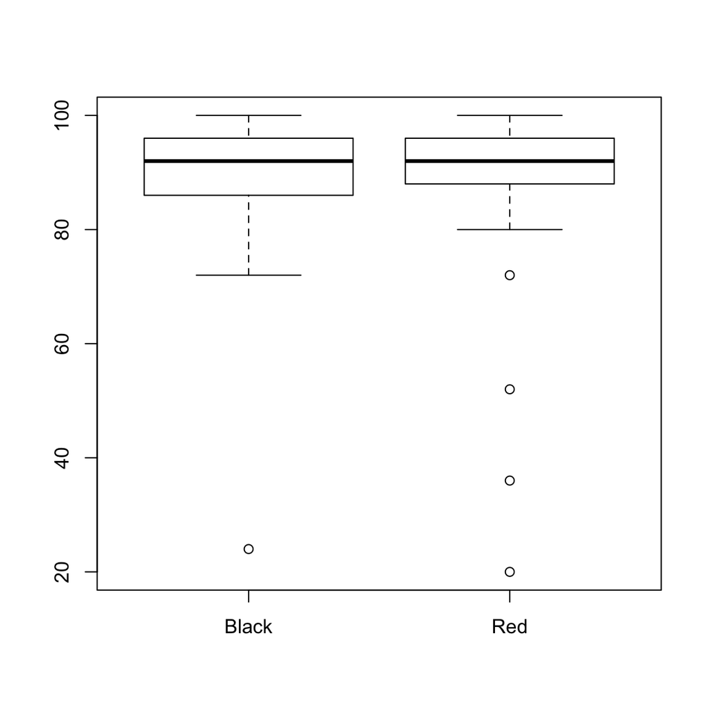

##### QQ plot

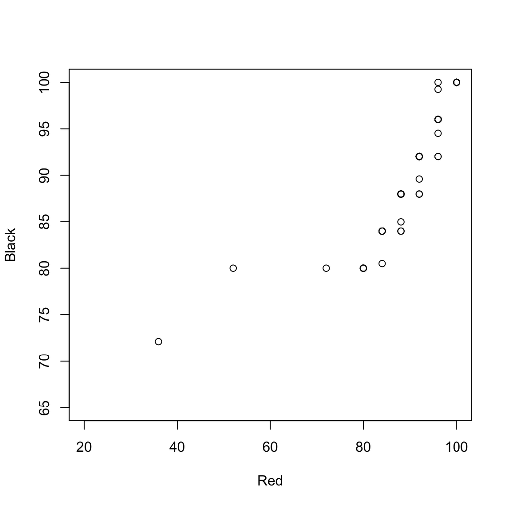

##### ECDF plot

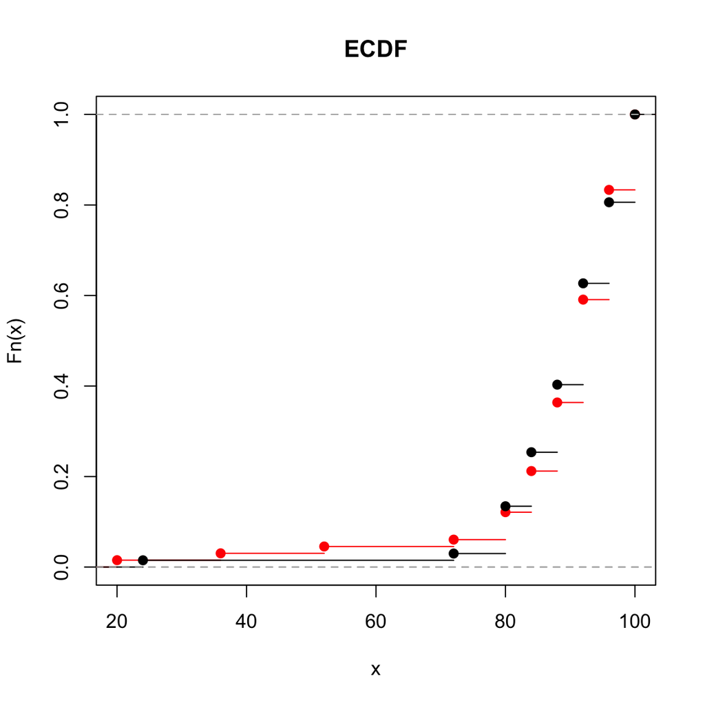

##### 문해력 등급 판정

- I수준(24점 이하), II수준(28 ~ 48점), III수준(52 ~ 72점), IV수준(76점 이상)

문해력 등급 분포

| I | II | III | IV | 결석 |
| --- | --- | --- | --- | --- |
| 2 | 1 | 3 | 127 | 23 |

그룹별 문해력 등급 분포

|  | I | II | III | IV | 결석 |
| --- | --- | --- | --- | --- | --- |
| **Black** | 1 | 0 | 1 | 65 | 13 |
| **Red** | 1 | 1 | 2 | 62 | 10 |

#### 문항 유형별 점수 분석

```r
type <- scan(file = "../data/literacy_type.txt", what = "")
type.kr <- factor(type, levels = c("a", "b", "c"), labels = c("사실적", "추론적", "비판적"))
```

##### 유형별 정답률

|  | 유형 | 정답률 |
| --- | --- | --- |
| **문1** | 사실적 | 100.0 |
| **문2** | 사실적 | 97.7 |
| **문3** | 비판적 | 88.0 |
| **문4** | 사실적 | 97.7 |
| **문5** | 추론적 | 95.5 |
| **문6** | 추론적 | 75.9 |
| **문7** | 추론적 | 97.0 |
| **문8** | 사실적 | 91.0 |
| **문9** | 추론적 | 59.4 |
| **문10** | 추론적 | 94.7 |
| **문11** | 사실적 | 96.2 |
| **문12** | 사실적 | 62.4 |
| **문13** | 사실적 | 94.7 |
| **문14** | 추론적 | 95.5 |
| **문15** | 사실적 | 85.7 |
| **문16** | 사실적 | 97.0 |
| **문17** | 추론적 | 78.2 |
| **문18** | 비판적 | 95.5 |
| **문19** | 사실적 | 97.7 |
| **문20** | 사실적 | 93.2 |
| **문21** | 사실적 | 94.0 |
| **문22** | 비판적 | 74.4 |
| **문23** | 추론적 | 95.5 |
| **문24** | 사실적 | 95.5 |
| **문25** | 추론적 | 91.7 |

#### 어려운 문제?

##### 정답률 80% 이하

| 문6 | 문9 | 문12 | 문17 | 문22 |
| --- | --- | --- | --- | --- |
| 75.94 | 59.4 | 62.41 | 78.2 | 74.44 |

##### 정답률 70% 이하

| 문9 | 문12 |
| --- | --- |
| 59.4 | 62.41 |

##### 정답률 60% 이하

|  | 문9 |
| --- | --- |
| **정답률** | 59.4 |